# Machine Learning Engineer Nanodegree Project (Starbucks Project)

## Project Overview

This project aims to identify consumers who will respond positively or favourably to a sales promotion offer made by starbucks. Starbucks dispenses messages to customers containing a type of offer. Offers made by Starbucks in these messages include the following: **buy-one-get-one (BOGO)**, **discount offers** and **informational offers**. Each customer receives one of these offers.

BOGO offers require that a customer spends a particular amount or purchases the required amount of items to qualify. Discount offers give customers the chance to purchase certain items at lesser value. The last category which is informational, is not necessarily an offer but merely gives information about certain products. Customers and consumers alike receive these offers through a variety of channels. These channels include: web, email, mobile and social media.

Generally, companies make offers or deploy ads to their customers for a number of reasons, this action is referred to as sales promotion. Some of the reasons for sales promotion include: increase sales, gain market share from competition, gain new distribution opportunities and so on. Sale promos demand a significant amount of resources and are only successful when the objectives are achieved.

## Problem Statement

Starbucks like any other organisation sends out promos to reward loyal customers, maximize profit and also gain new customers. The typical flow of an appropriate offer begins with **"Offer Recieved"**. The next stage is **"Offer Viewed"**. at this stage it is expected that the customer has viewed the offer. The third stage is **"Transaction"**, whereby the customer makes a transaction in accordance with the offer viewed. The last stage is **"Offer Completed"** in which the customer has completed the demands of the offer and made the appropriate transactions.

Considering the preceding, it is discovered that some consumers do not complete the offer. In certain cases, offers are only received and not viewed while others are viewed and no transaction is conducted. There are also cases where transactions not impacted by offers are conducted. The preceding scenarios which depict incomplete offers, points to the inability to match customers with offers they are prone to completing. As such, this project sets determine if a particular customer will respond to an offer or not.

For the purpose of solving the above stated problem, a classifier will be trained to determine if a customer will respond to a particular offer or not. The project will also identify the features that customers consider before responding to an offer. There (3) distinct classifiers **(Logistic Regression, Random Forest Classifier, Gradient Boosting)** will be trained with the data and their results compared with each other. The classifier or model with the highest accuracy will be chosen.

## Metrics

For this project, a confusion matrix will be generated detailing the True Positives (TP), False Positives (FP), False Negatives (FN), True Negatives (TN). The purpose of this is to depict the number of correct and wrong predictions made by the model. After this, the model’s accuracy score will be generated. Accuracy measures the ratio of correct predictions over the total number of instances evaluated. Formula for accuracy: (TP+TN)/(TP+TN+FP+FN)

```python
#importing the necessary libraries for this project
%matplotlib inline
import pandas as pd
import numpy as np
import matplotlib.pyplot as plt
import seaborn as sns

#importing the models and tools to be used in this project
from sklearn.preprocessing import MinMaxScaler
from sklearn.model_selection import train_test_split
from sklearn.linear_model import LogisticRegression
from sklearn.ensemble import RandomForestClassifier, GradientBoostingClassifier
from sklearn.metrics import confusion_matrix

#initializing the scaler to be used
scaler = MinMaxScaler()

#initializing the models that will be used
lr = LogisticRegression(random_state=42)
rfc = RandomForestClassifier(random_state=42)
gbc = GradientBoostingClassifier(random_state=42)

#reading the dataset(s) for this project
portfolio = pd.read_csv('/Users/mac/Downloads/Starbucks proposal and dataset/portfolio.csv')
profile = pd.read_csv('/Users/mac/Downloads/Starbucks proposal and dataset/profile.csv')
transcript = pd.read_csv('/Users/mac/Downloads/Starbucks proposal and dataset/transcript.csv')
```

# 1. Data Exploration and Cleaning

This section involves exploring the dataset to know distinct columns and values, checking for duplicates, handling missing data and clreating new features from existing ones

## 1.1 Portfolio Dataset

```python
#viewing the porfolio dataset
portfolio
```

|  | reward | channels | difficulty | duration | offer_type | id |
| --- | --- | --- | --- | --- | --- | --- |
| 0 | 10 | ['email', 'mobile', 'social'] | 10 | 7 | bogo | ae264e3637204a6fb9bb56bc8210ddfd |
| 1 | 10 | ['web', 'email', 'mobile', 'social'] | 10 | 5 | bogo | 4d5c57ea9a6940dd891ad53e9dbe8da0 |
| 2 | 0 | ['web', 'email', 'mobile'] | 0 | 4 | informational | 3f207df678b143eea3cee63160fa8bed |
| 3 | 5 | ['web', 'email', 'mobile'] | 5 | 7 | bogo | 9b98b8c7a33c4b65b9aebfe6a799e6d9 |
| 4 | 5 | ['web', 'email'] | 20 | 10 | discount | 0b1e1539f2cc45b7b9fa7c272da2e1d7 |
| 5 | 3 | ['web', 'email', 'mobile', 'social'] | 7 | 7 | discount | 2298d6c36e964ae4a3e7e9706d1fb8c2 |
| 6 | 2 | ['web', 'email', 'mobile', 'social'] | 10 | 10 | discount | fafdcd668e3743c1bb461111dcafc2a4 |
| 7 | 0 | ['email', 'mobile', 'social'] | 0 | 3 | informational | 5a8bc65990b245e5a138643cd4eb9837 |
| 8 | 5 | ['web', 'email', 'mobile', 'social'] | 5 | 5 | bogo | f19421c1d4aa40978ebb69ca19b0e20d |
| 9 | 2 | ['web', 'email', 'mobile'] | 10 | 7 | discount | 2906b810c7d4411798c6938adc9daaa5 |

from the dataset above, we can see that there are a 6 columns. Generally, we can see that the dataset needs cleaning.

```python
#rename the 'id' column as 'offer_id'
portfolio.rename(columns={'id': 'offer_id'}, inplace=True)

#one_hot_encoding the 'offer_type' column
offers = pd.get_dummies(portfolio['offer_type'])
clean_portfolio = pd.concat([portfolio, offers], axis = 1)

#Seperating list values in 'channels' column into new columns and also one_hot_encodes them
def list_breaker(df, column, value):

    """
    This function seperates the 'channels' column into new columns and also one_hot_encodes them
    ARGS:
        df - dataset
        column - specific column to be worked on
        value - for each value in the lists, (i.e, 'email', 'web', 'social', 'mobile')
    """

    df[value] = df[column].apply(lambda x: 1 if value in x else 0)
    return df

#if left at the function above, the function will have to be called multiple times.
#To avoid this, another function will be created to iterate over the values
def applier(df):
    """
    ARGS:
        df - dataset
    """
    values = ['web', 'email', 'mobile', 'social']
    for value in values:
        result = list_breaker(df, 'channels', value) #previous function created is called
        print(result)

#calling the applier function
applier(clean_portfolio)

#transforming the 'duration' column values from days to hours, multiplying values by 24
clean_portfolio['duration_by_hours'] = clean_portfolio['duration']*24
clean_portfolio
```

[output not shown]

[output cut: 125 more lines]

|  | reward | channels | difficulty | duration | offer_type | offer_id | bogo | discount | informational | web | email | mobile | social | duration_by_hours |
| --- | --- | --- | --- | --- | --- | --- | --- | --- | --- | --- | --- | --- | --- | --- |
| 0 | 10 | ['email', 'mobile', 'social'] | 10 | 7 | bogo | ae264e3637204a6fb9bb56bc8210ddfd | 1 | 0 | 0 | 0 | 1 | 1 | 1 | 168 |
| 1 | 10 | ['web', 'email', 'mobile', 'social'] | 10 | 5 | bogo | 4d5c57ea9a6940dd891ad53e9dbe8da0 | 1 | 0 | 0 | 1 | 1 | 1 | 1 | 120 |
| 2 | 0 | ['web', 'email', 'mobile'] | 0 | 4 | informational | 3f207df678b143eea3cee63160fa8bed | 0 | 0 | 1 | 1 | 1 | 1 | 0 | 96 |
| 3 | 5 | ['web', 'email', 'mobile'] | 5 | 7 | bogo | 9b98b8c7a33c4b65b9aebfe6a799e6d9 | 1 | 0 | 0 | 1 | 1 | 1 | 0 | 168 |
| 4 | 5 | ['web', 'email'] | 20 | 10 | discount | 0b1e1539f2cc45b7b9fa7c272da2e1d7 | 0 | 1 | 0 | 1 | 1 | 0 | 0 | 240 |
| 5 | 3 | ['web', 'email', 'mobile', 'social'] | 7 | 7 | discount | 2298d6c36e964ae4a3e7e9706d1fb8c2 | 0 | 1 | 0 | 1 | 1 | 1 | 1 | 168 |
| 6 | 2 | ['web', 'email', 'mobile', 'social'] | 10 | 10 | discount | fafdcd668e3743c1bb461111dcafc2a4 | 0 | 1 | 0 | 1 | 1 | 1 | 1 | 240 |
| 7 | 0 | ['email', 'mobile', 'social'] | 0 | 3 | informational | 5a8bc65990b245e5a138643cd4eb9837 | 0 | 0 | 1 | 0 | 1 | 1 | 1 | 72 |
| 8 | 5 | ['web', 'email', 'mobile', 'social'] | 5 | 5 | bogo | f19421c1d4aa40978ebb69ca19b0e20d | 1 | 0 | 0 | 1 | 1 | 1 | 1 | 120 |
| 9 | 2 | ['web', 'email', 'mobile'] | 10 | 7 | discount | 2906b810c7d4411798c6938adc9daaa5 | 0 | 1 | 0 | 1 | 1 | 1 | 0 | 168 |

```python
#dropping unnecessary columns
clean_portfolio.drop(columns = ['offer_type', 'duration', 'channels'], axis = 1, inplace = True)
clean_portfolio
```

|  | reward | difficulty | offer_id | bogo | discount | informational | web | email | mobile | social | duration_by_hours |
| --- | --- | --- | --- | --- | --- | --- | --- | --- | --- | --- | --- |
| 0 | 10 | 10 | ae264e3637204a6fb9bb56bc8210ddfd | 1 | 0 | 0 | 0 | 1 | 1 | 1 | 168 |
| 1 | 10 | 10 | 4d5c57ea9a6940dd891ad53e9dbe8da0 | 1 | 0 | 0 | 1 | 1 | 1 | 1 | 120 |
| 2 | 0 | 0 | 3f207df678b143eea3cee63160fa8bed | 0 | 0 | 1 | 1 | 1 | 1 | 0 | 96 |
| 3 | 5 | 5 | 9b98b8c7a33c4b65b9aebfe6a799e6d9 | 1 | 0 | 0 | 1 | 1 | 1 | 0 | 168 |
| 4 | 5 | 20 | 0b1e1539f2cc45b7b9fa7c272da2e1d7 | 0 | 1 | 0 | 1 | 1 | 0 | 0 | 240 |
| 5 | 3 | 7 | 2298d6c36e964ae4a3e7e9706d1fb8c2 | 0 | 1 | 0 | 1 | 1 | 1 | 1 | 168 |
| 6 | 2 | 10 | fafdcd668e3743c1bb461111dcafc2a4 | 0 | 1 | 0 | 1 | 1 | 1 | 1 | 240 |
| 7 | 0 | 0 | 5a8bc65990b245e5a138643cd4eb9837 | 0 | 0 | 1 | 0 | 1 | 1 | 1 | 72 |
| 8 | 5 | 5 | f19421c1d4aa40978ebb69ca19b0e20d | 1 | 0 | 0 | 1 | 1 | 1 | 1 | 120 |
| 9 | 2 | 10 | 2906b810c7d4411798c6938adc9daaa5 | 0 | 1 | 0 | 1 | 1 | 1 | 0 | 168 |

## 1.2 Profile Dataset

```python
#viewing the profile dataset
profile.head()
```

|  | gender | age | id | became_member_on | income |
| --- | --- | --- | --- | --- | --- |
| 0 | NaN | 118 | 68be06ca386d4c31939f3a4f0e3dd783 | 20170212 | NaN |
| 1 | F | 55 | 0610b486422d4921ae7d2bf64640c50b | 20170715 | 112000.0 |
| 2 | NaN | 118 | 38fe809add3b4fcf9315a9694bb96ff5 | 20180712 | NaN |
| 3 | F | 75 | 78afa995795e4d85b5d9ceeca43f5fef | 20170509 | 100000.0 |
| 4 | NaN | 118 | a03223e636434f42ac4c3df47e8bac43 | 20170804 | NaN |

from the dataset above, we can see that there are null values. the next step will be to get the rows were there are null values

```python
null_profile_values = profile[profile['gender'].isnull()]
null_profile_values['age'].unique()
```

```
array([118])
```

The above tells us that the null values have only '118' as the age. Therefore the next step will be to drop the null values as identified previously

```python
profile.drop(index = null_profile_values.index, inplace = True)

#to confirm there are no more null values in the profile dataset, we confirm with this:
profile.isnull().sum()
```

```
gender              0
age                 0
id                  0
became_member_on    0
income              0
dtype: int64
```

```python
#cleaning the profile dataset

#now that null values are taken care of, we will move on to cleaning the profile dataset.

#transforming the 'became_member_on' column to date format

from datetime import datetime #importing the datetime module to be used
profile['became_member_on'] = pd.to_datetime(profile['became_member_on'], format = '%Y%m%d')

#next we seperate the dates in the 'became_member_on' column into distinct columns:
#'became_member_year (year)'
# became_member_month (month)
# became_member_day (day)
#we will furthermore, calculate the period the customers have been members.
def date_seperator(profile):
    """
    This function seperates the date column 'became_member_on' into disctinct columns itemized above
    ARGS:
        profile - profile dataset
    """
    profile['became_member_year'] = pd.to_datetime(profile['became_member_on'],format='%Y%m%d').dt.year
    profile['became_member_month'] = pd.to_datetime(profile['became_member_on'],format='%Y%m%d').dt.month
    profile['became_member_day'] = pd.to_datetime(profile['became_member_on'],format='%Y%m%d').dt.day
    profile['membership_tenure'] = (datetime.today().date() - pd.to_datetime(profile['became_member_on'],format='%Y%m%d').dt.date).dt.days
    return profile

date_seperator(profile)

#creating age_grade column from 'age' column in the profile dataset
profile['age_grade'] = pd.cut(profile['age'], bins=range(10,120,10),right=False,
              labels=['10s','20s', '30s', '40s', '50s','60s', '70s', '80s', '90s', '100s'])

#creating income_range column from 'income' column in the dataset
profile['income_range'] = pd.cut(profile['income'], bins=range(30000,140000,10000), right=False,
                                          labels=['30ths','40ths', '50ths',
                                                  '60ths', '70ths','80ths',
                                                  '90ths', '100ths', '110ths', '120ths'])


#one_hot_encoding the 'became_member_year', 'became_member_month', 'income_range', 'age_grade' columns
def one_hot_encoder(df, column, value):
    """
    This function creates dummies for any column keyed in
    ARGS:
        df - dataset
        column - column to be one_hot_encoded
        value - the value that will serve as prefix (see the line of return below)
    """
    return pd.get_dummies(profile[column], prefix = value, prefix_sep = '_')

#creating the columns mentioned above the calling the functions
age_grade_dummies = one_hot_encoder(profile, 'age_grade', 'age_grade')
income_range_dummies = one_hot_encoder(profile, 'income_range', 'income_range')
year_membership_dummies = one_hot_encoder(profile, 'became_member_year', 'year')
month_membership_dummies = one_hot_encoder(profile, 'became_member_month', 'month')
gender_dummies = one_hot_encoder(profile, 'gender', 'gender')

#creating a cleaned dataset by joining the one_hot_encoded values to the profile dataset
clean_profile = pd.concat([profile, age_grade_dummies, income_range_dummies,
                          year_membership_dummies, month_membership_dummies,gender_dummies]
                          , axis = 1)

#renaming the id column to customer_id
clean_profile.rename(columns={'id': 'customer_id'}, inplace=True)

clean_profile
```

|  | gender | age | customer_id | became_member_on | income | became_member_year | became_member_month | became_member_day | membership_tenure | age_grade | ... | month_6 | month_7 | month_8 | month_9 | month_10 | month_11 | month_12 | gender_F | gender_M | gender_O |
| --- | --- | --- | --- | --- | --- | --- | --- | --- | --- | --- | --- | --- | --- | --- | --- | --- | --- | --- | --- | --- | --- |
| 1 | F | 55 | 0610b486422d4921ae7d2bf64640c50b | 2017-07-15 | 112000.0 | 2017 | 7 | 15 | 1284 | 50s | ... | 0 | 1 | 0 | 0 | 0 | 0 | 0 | 1 | 0 | 0 |
| 3 | F | 75 | 78afa995795e4d85b5d9ceeca43f5fef | 2017-05-09 | 100000.0 | 2017 | 5 | 9 | 1351 | 70s | ... | 0 | 0 | 0 | 0 | 0 | 0 | 0 | 1 | 0 | 0 |
| 5 | M | 68 | e2127556f4f64592b11af22de27a7932 | 2018-04-26 | 70000.0 | 2018 | 4 | 26 | 999 | 60s | ... | 0 | 0 | 0 | 0 | 0 | 0 | 0 | 0 | 1 | 0 |
| 8 | M | 65 | 389bc3fa690240e798340f5a15918d5c | 2018-02-09 | 53000.0 | 2018 | 2 | 9 | 1075 | 60s | ... | 0 | 0 | 0 | 0 | 0 | 0 | 0 | 0 | 1 | 0 |
| 12 | M | 58 | 2eeac8d8feae4a8cad5a6af0499a211d | 2017-11-11 | 51000.0 | 2017 | 11 | 11 | 1165 | 50s | ... | 0 | 0 | 0 | 0 | 0 | 1 | 0 | 0 | 1 | 0 |
| ... | ... | ... | ... | ... | ... | ... | ... | ... | ... | ... | ... | ... | ... | ... | ... | ... | ... | ... | ... | ... | ... |
| 16995 | F | 45 | 6d5f3a774f3d4714ab0c092238f3a1d7 | 2018-06-04 | 54000.0 | 2018 | 6 | 4 | 960 | 40s | ... | 1 | 0 | 0 | 0 | 0 | 0 | 0 | 1 | 0 | 0 |
| 16996 | M | 61 | 2cb4f97358b841b9a9773a7aa05a9d77 | 2018-07-13 | 72000.0 | 2018 | 7 | 13 | 921 | 60s | ... | 0 | 1 | 0 | 0 | 0 | 0 | 0 | 0 | 1 | 0 |
| 16997 | M | 49 | 01d26f638c274aa0b965d24cefe3183f | 2017-01-26 | 73000.0 | 2017 | 1 | 26 | 1454 | 40s | ... | 0 | 0 | 0 | 0 | 0 | 0 | 0 | 0 | 1 | 0 |
| 16998 | F | 83 | 9dc1421481194dcd9400aec7c9ae6366 | 2016-03-07 | 50000.0 | 2016 | 3 | 7 | 1779 | 80s | ... | 0 | 0 | 0 | 0 | 0 | 0 | 0 | 1 | 0 | 0 |
| 16999 | F | 62 | e4052622e5ba45a8b96b59aba68cf068 | 2017-07-22 | 82000.0 | 2017 | 7 | 22 | 1277 | 60s | ... | 0 | 1 | 0 | 0 | 0 | 0 | 0 | 1 | 0 | 0 |

14825 rows × 52 columns

### 1.2.1 Data Visualization of Profile Datatset

```python
#In plotting elements from the Profile Dataset, we will be plotting the following items
# Income_range Frequency distribution
# Age_grade frequency distribution
# Gender Frequency distribtuion
# Gender distribution by year
# Income_range distribution by year
# Age_grade distribution by year

#We will make use of the following functions
def distribution_plotter(df, column, colour):
    """
    This function will plot the distribution of the desired column
    ARGS:
        df - dataset
        column - desired column
        colour - desired colour of the bar chart
    """
    x = df[column].unique() #the unique values will form the x axis
    y = clean_profile[column].value_counts() #Frequency
    fig=plt.figure(figsize = (10,6)) #size of bar_chart
    plt.xlabel(column)
    plt.ylabel('Frequency')
    plt.title('{} distribution'.format(column))
    plt.bar(x,y, color = colour)


#Plotting desired column by year
def double_distribution_plotter(df, primary_column, column):
    """
    This function will plot the distribution of the desired column by year
    ARGS:
        df - dataset
        primary_column - column to group by
        column - desired column
        colour - desired colour of the bar chart
    """
    collated_set = df.groupby([primary_column, column]).size()
    collated_set = collated_set.reset_index()
    collated_set.columns = [primary_column, column, 'count']

    plt.figure(figsize = (10,5))
    sns.barplot(x = primary_column, y = 'count', hue = column, data = collated_set)
    plt.xlabel('Year')
    plt.ylabel('Frequency')
    plt.title('{} counts by {}'.format(column, 'year'))
```

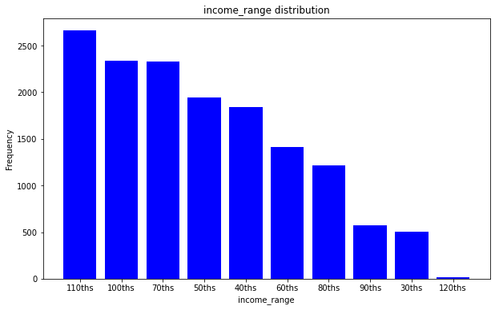

```python
# Income_range Frequency distribution
distribution_plotter(clean_profile, 'income_range', 'blue')
```

### Income Distribution

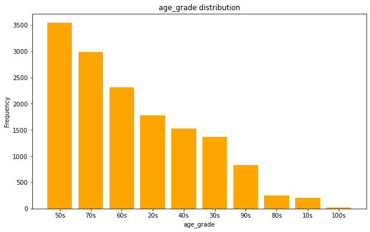

```python
# Age_grade frequency distribution
distribution_plotter(clean_profile, 'age_grade', 'orange')
```

### Age Distribution

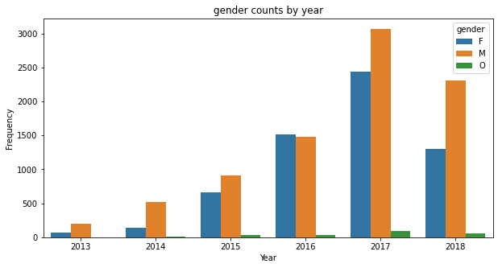

```python
# Gender distribution by year
double_distribution_plotter(clean_profile, 'became_member_year', 'gender')
```

### Gender Distribution by Year

This graph depicts the gender distribution by year. Except for 2016, all other years had more males subscribing to Starbucks.

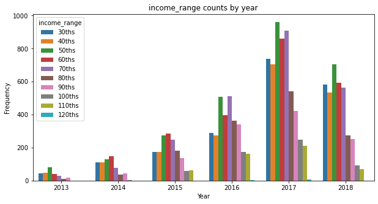

```python
# Income_range distribution by year
double_distribution_plotter(clean_profile, 'became_member_year', 'income_range')
```

### Income Range by Year

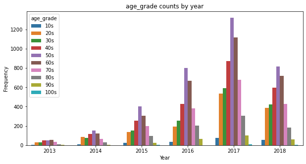

```python
# Age_grade distribution by year
double_distribution_plotter(clean_profile, 'became_member_year', 'age_grade')
```

### Age Distribution by Year

This chart depics the ages of people who subscribed to Starbucks every year from 2013 to 2018. From the chart, we can tell that between 2014 to 2018, the age of people you obtained membership were with the 50s age bracker. 2013 was however different as it saw more people within the 60s age bracket

```python
#getting list of columns in the dataset
clean_profile.columns.tolist()
```

```
['gender',
 'age',
 'customer_id',
 'became_member_on',
 'income',
 'became_member_year',
 'became_member_month',
 'became_member_day',
 'membership_tenure',
 'age_grade',
 'income_range',
 'age_grade_10s',
 'age_grade_20s',
 'age_grade_30s',
 'age_grade_40s',
 'age_grade_50s',
 'age_grade_60s',
 'age_grade_70s',
 'age_grade_80s',
 'age_grade_90s',
 'age_grade_100s',
 'income_range_30ths',
 'income_range_40ths',
 'income_range_50ths',
 'income_range_60ths',
 'income_range_70ths',
 'income_range_80ths',
 'income_range_90ths',
 'income_range_100ths',
 'income_range_110ths',
 'income_range_120ths',
 'year_2013',
 'year_2014',
 'year_2015',
 'year_2016',
 'year_2017',
 'year_2018',
 'month_1',
 'month_2',
 'month_3',
 'month_4',
 'month_5',
 'month_6',
 'month_7',
 'month_8',
 'month_9',
 'month_10',
 'month_11',
 'month_12',
 'gender_F',
 'gender_M',
 'gender_O']
```

```python
#dropping the unnecessary columns in the dataset
cols_to_drop = ['gender', 'age', 'became_member_on', 'income', 'age_grade', 'income_range', 'became_member_year',
               'became_member_month']
clean_profile.drop(columns = ['gender', 'age', 'became_member_on', 'income', 'age_grade', 'income_range', 'became_member_year',
               'became_member_month'], axis = 1, inplace = True)
```

```python
clean_profile
```

|  | customer_id | became_member_day | membership_tenure | age_grade_10s | age_grade_20s | age_grade_30s | age_grade_40s | age_grade_50s | age_grade_60s | age_grade_70s | ... | month_6 | month_7 | month_8 | month_9 | month_10 | month_11 | month_12 | gender_F | gender_M | gender_O |
| --- | --- | --- | --- | --- | --- | --- | --- | --- | --- | --- | --- | --- | --- | --- | --- | --- | --- | --- | --- | --- | --- |
| 1 | 0610b486422d4921ae7d2bf64640c50b | 15 | 1284 | 0 | 0 | 0 | 0 | 1 | 0 | 0 | ... | 0 | 1 | 0 | 0 | 0 | 0 | 0 | 1 | 0 | 0 |
| 3 | 78afa995795e4d85b5d9ceeca43f5fef | 9 | 1351 | 0 | 0 | 0 | 0 | 0 | 0 | 1 | ... | 0 | 0 | 0 | 0 | 0 | 0 | 0 | 1 | 0 | 0 |
| 5 | e2127556f4f64592b11af22de27a7932 | 26 | 999 | 0 | 0 | 0 | 0 | 0 | 1 | 0 | ... | 0 | 0 | 0 | 0 | 0 | 0 | 0 | 0 | 1 | 0 |
| 8 | 389bc3fa690240e798340f5a15918d5c | 9 | 1075 | 0 | 0 | 0 | 0 | 0 | 1 | 0 | ... | 0 | 0 | 0 | 0 | 0 | 0 | 0 | 0 | 1 | 0 |
| 12 | 2eeac8d8feae4a8cad5a6af0499a211d | 11 | 1165 | 0 | 0 | 0 | 0 | 1 | 0 | 0 | ... | 0 | 0 | 0 | 0 | 0 | 1 | 0 | 0 | 1 | 0 |
| ... | ... | ... | ... | ... | ... | ... | ... | ... | ... | ... | ... | ... | ... | ... | ... | ... | ... | ... | ... | ... | ... |
| 16995 | 6d5f3a774f3d4714ab0c092238f3a1d7 | 4 | 960 | 0 | 0 | 0 | 1 | 0 | 0 | 0 | ... | 1 | 0 | 0 | 0 | 0 | 0 | 0 | 1 | 0 | 0 |
| 16996 | 2cb4f97358b841b9a9773a7aa05a9d77 | 13 | 921 | 0 | 0 | 0 | 0 | 0 | 1 | 0 | ... | 0 | 1 | 0 | 0 | 0 | 0 | 0 | 0 | 1 | 0 |
| 16997 | 01d26f638c274aa0b965d24cefe3183f | 26 | 1454 | 0 | 0 | 0 | 1 | 0 | 0 | 0 | ... | 0 | 0 | 0 | 0 | 0 | 0 | 0 | 0 | 1 | 0 |
| 16998 | 9dc1421481194dcd9400aec7c9ae6366 | 7 | 1779 | 0 | 0 | 0 | 0 | 0 | 0 | 0 | ... | 0 | 0 | 0 | 0 | 0 | 0 | 0 | 1 | 0 | 0 |
| 16999 | e4052622e5ba45a8b96b59aba68cf068 | 22 | 1277 | 0 | 0 | 0 | 0 | 0 | 1 | 0 | ... | 0 | 1 | 0 | 0 | 0 | 0 | 0 | 1 | 0 | 0 |

14825 rows × 44 columns

## 1.3 Transcript Dataset

```python
#loading the first five rows of the dataset
transcript.head()
```

|  | person | event | value | time |
| --- | --- | --- | --- | --- |
| 0 | 78afa995795e4d85b5d9ceeca43f5fef | offer received | {'offer id': '9b98b8c7a33c4b65b9aebfe6a799e6d9'} | 0 |
| 1 | a03223e636434f42ac4c3df47e8bac43 | offer received | {'offer id': '0b1e1539f2cc45b7b9fa7c272da2e1d7'} | 0 |
| 2 | e2127556f4f64592b11af22de27a7932 | offer received | {'offer id': '2906b810c7d4411798c6938adc9daaa5'} | 0 |
| 3 | 8ec6ce2a7e7949b1bf142def7d0e0586 | offer received | {'offer id': 'fafdcd668e3743c1bb461111dcafc2a4'} | 0 |
| 4 | 68617ca6246f4fbc85e91a2a49552598 | offer received | {'offer id': '4d5c57ea9a6940dd891ad53e9dbe8da0'} | 0 |

```python
#checking for null values in the dataset
transcript.isnull().sum()
```

```
person    0
event     0
value     0
time      0
dtype: int64
```

```python
#Since there are no null values in the dataset, we move on to other cleaning processes

#Changing the name of the column from 'Person' to 'customer_id'
transcript.rename(columns = {'person':'customer_id'}, inplace = True)

#Removing IDs that belong to those with '118' as age
id_age_118 = null_profile_values['id'].unique().tolist()
transcript['customer_id'].isin(id_age_118).value_counts()

#Dropping the rows where IDs (in the transcript dataset) match those that belong to people aged 118
transcript = transcript[~transcript['customer_id'].isin(id_age_118)]

#We are done with the cleaning. The next task is to seperate the transcript data into offers_df and transaction_df
#This will make it easy to seperate the dict values accordingly
offer_events = ['offer received', 'offer viewed', 'offer completed']
offer_index = transcript[transcript['event'].isin(offer_events)].index
transaction_index = transcript[~transcript['event'].isin(offer_events)].index
offers_df = transcript.loc[offer_index,:]
transaction_df = transcript.loc[transaction_index,:]

#While the two columns are now seperated, we see that the dict values in the value column are not cleaned
#That's the next task. This will be done by creating two functions: offers_value_extractor and transaction_values_extractor

def offers_value_extractor(df, column, value1, value2):
    """
    This function will seperate the dict values in the offers_df
    ARGS:
        df - dataset
        column - column to be seperated
        value1 - the value to be replaced
        value2 - the value that will replace value 1
        it was noticed in the transcript dataset that some rows in the value column have 'offer id' instead of offer_id
        hence, this will be replaced before extracting the values
    """
    df[column] = df[column].str.replace(value1, value2)
    list_of_values = df[column].map(eval)
    result = pd.DataFrame(list_of_values.tolist())
    return result

def transaction_value_extractor(df, column):
    """
    This function will seperate the dict values in the transaction_df
    ARGS:
        df - dataset
        column - column to be seperated
    """
    list_of_values = df[column].map(eval)
    result = pd.DataFrame(list_of_values.tolist())
    return result

#Now we will call the extractor functions created and concat the columns to their respective dataset
offers_id = offers_value_extractor(offers_df, 'value', 'offer id', 'offer_id')
transaction_amount = transaction_value_extractor(transaction_df, 'value')
offers_df = pd.concat([offers_df.reset_index(drop = True),
                           offers_id.reset_index(drop = True)], axis = 1)
transaction_df = pd.concat([transaction_df.reset_index(drop = True), transaction_amount], axis = 1)
```

```python
#viewing the created datasets
offers_df, transaction_df
```

```
(                             customer_id            event  \
 0       78afa995795e4d85b5d9ceeca43f5fef   offer received
 1       e2127556f4f64592b11af22de27a7932   offer received
 2       389bc3fa690240e798340f5a15918d5c   offer received
 3       2eeac8d8feae4a8cad5a6af0499a211d   offer received
 4       aa4862eba776480b8bb9c68455b8c2e1   offer received
 ...                                  ...              ...
 148800  84fb57a7fe8045a8bf6236738ee73a0f     offer viewed
 148801  abc4359eb34e4e2ca2349da2ddf771b6     offer viewed
 148802  8dda575c2a1d44b9ac8e8b07b93d1f8e     offer viewed
 148803  8431c16f8e1d440880db371a68f82dd0  offer completed
 148804  24f56b5e1849462093931b164eb803b5  offer completed

                                                     value  time  \
 0        {'offer_id': '9b98b8c7a33c4b65b9aebfe6a799e6d9'}     0
```

[output cut: 52 more lines]

```python
#we will now drop the value column from the two datasets created. This will be achieved with a function drop_col
#We will also get the dummies of the 'events' column

def drop_col (df, column):
    """
    This function will drop the specified column
    ARGS:
        df - dataset
        column - column to be dropped
    """
    df.drop(column, axis = 1, inplace = True)
    return df

#Calling the drop_col function on the datasets created
drop_col(offers_df, 'value')
drop_col(transaction_df, 'value')

#Getting dummies for the event column in the offer dataset
offers_df = pd.get_dummies(offers_df, columns = ['event'], prefix = '', prefix_sep = '')
offers_df

#We are now going to reorder the columns in the offers_df dataset
col_order = ['customer_id', 'offer_id', 'time', 'offer received', 'offer viewed', 'offer completed']
offers_df = offers_df.reindex(col_order, axis=1)
offers_df
```

|  | customer_id | offer_id | time | offer received | offer viewed | offer completed |
| --- | --- | --- | --- | --- | --- | --- |
| 0 | 78afa995795e4d85b5d9ceeca43f5fef | 9b98b8c7a33c4b65b9aebfe6a799e6d9 | 0 | 1 | 0 | 0 |
| 1 | e2127556f4f64592b11af22de27a7932 | 2906b810c7d4411798c6938adc9daaa5 | 0 | 1 | 0 | 0 |
| 2 | 389bc3fa690240e798340f5a15918d5c | f19421c1d4aa40978ebb69ca19b0e20d | 0 | 1 | 0 | 0 |
| 3 | 2eeac8d8feae4a8cad5a6af0499a211d | 3f207df678b143eea3cee63160fa8bed | 0 | 1 | 0 | 0 |
| 4 | aa4862eba776480b8bb9c68455b8c2e1 | 0b1e1539f2cc45b7b9fa7c272da2e1d7 | 0 | 1 | 0 | 0 |
| ... | ... | ... | ... | ... | ... | ... |
| 148800 | 84fb57a7fe8045a8bf6236738ee73a0f | 5a8bc65990b245e5a138643cd4eb9837 | 714 | 0 | 1 | 0 |
| 148801 | abc4359eb34e4e2ca2349da2ddf771b6 | 3f207df678b143eea3cee63160fa8bed | 714 | 0 | 1 | 0 |
| 148802 | 8dda575c2a1d44b9ac8e8b07b93d1f8e | 0b1e1539f2cc45b7b9fa7c272da2e1d7 | 714 | 0 | 1 | 0 |
| 148803 | 8431c16f8e1d440880db371a68f82dd0 | fafdcd668e3743c1bb461111dcafc2a4 | 714 | 0 | 0 | 1 |
| 148804 | 24f56b5e1849462093931b164eb803b5 | fafdcd668e3743c1bb461111dcafc2a4 | 714 | 0 | 0 | 1 |

148805 rows × 6 columns

```python
#Checking the transaction_df dataset to see if everything is as we want it
transaction_df
```

|  | customer_id | event | time | amount |
| --- | --- | --- | --- | --- |
| 0 | 02c083884c7d45b39cc68e1314fec56c | transaction | 0 | 0.83 |
| 1 | 9fa9ae8f57894cc9a3b8a9bbe0fc1b2f | transaction | 0 | 34.56 |
| 2 | 54890f68699049c2a04d415abc25e717 | transaction | 0 | 13.23 |
| 3 | b2f1cd155b864803ad8334cdf13c4bd2 | transaction | 0 | 19.51 |
| 4 | fe97aa22dd3e48c8b143116a8403dd52 | transaction | 0 | 18.97 |
| ... | ... | ... | ... | ... |
| 123952 | 24f56b5e1849462093931b164eb803b5 | transaction | 714 | 22.64 |
| 123953 | b3a1272bc9904337b331bf348c3e8c17 | transaction | 714 | 1.59 |
| 123954 | 68213b08d99a4ae1b0dcb72aebd9aa35 | transaction | 714 | 9.53 |
| 123955 | a00058cf10334a308c68e7631c529907 | transaction | 714 | 3.61 |
| 123956 | 76ddbd6576844afe811f1a3c0fbb5bec | transaction | 714 | 3.53 |

123957 rows × 4 columns

```python
def create_combined_data(portfolio, profile, offers_df, transaction_df):


    """
    Create a combined dataframe from the transaction, demographic and offer data:
    ARGS:
        portfolio - (dataframe),offer metadata
        profile - (dataframe),customer demographic data
        offers_df - (dataframe), offers data for customers
        transaction_df - (dataframe), transaction data for customers
    """

    combined_data = [] # Initialize empty list for combined data
    customer_id_list = offers_df['customer_id'].unique().tolist() # List of unique customers in offers_df


    # Iterate over each customer
    for i, cust_id in enumerate(customer_id_list):

        # select customer profile from profile data
        cust_profile = clean_profile[clean_profile['customer_id'] == cust_id]

        # select offers associated with the customer from offers_df
        cust_offers_data = offers_df[offers_df['customer_id'] == cust_id]

        # select transactions associated with the customer from transactions_df
        cust_transaction_df = transaction_df[transaction_df['customer_id'] == cust_id]

        # select received, completed, viewed offer data from customer offers
        offer_received_data  = cust_offers_data[cust_offers_data['offer received'] == 1]
        offer_viewed_data = cust_offers_data[cust_offers_data['offer viewed'] == 1]
        offer_completed_data = cust_offers_data[cust_offers_data['offer completed'] == 1]

        # Iterate over each offer received by a customer
        rows = [] # Initialize empty list for a customer records

        for off_id in offer_received_data['offer_id'].values.tolist():

            # select duration of a particular offer_id
            duration = clean_portfolio.loc[clean_portfolio['offer_id'] == off_id, 'duration_by_hours'].values[0]

            # select the time when offer was received
            off_recd_time = offer_received_data.loc[offer_received_data['offer_id'] == off_id, 'time'].values[0]

            # Calculate the time when the offer ends
            off_end_time = off_recd_time + duration

            #Initialize a boolean array that determines if the customer viewed an offer between offer period
            offers_viewed = np.logical_and(offer_viewed_data['time'] >= off_recd_time,offer_viewed_data['time'] <= off_end_time)

            # Check if the offer type is 'bogo' or 'discount'
            if (clean_portfolio[clean_portfolio['offer_id'] == off_id]['bogo'].values[0] == 1 or\
                    clean_portfolio[clean_portfolio['offer_id'] == off_id]['discount'].values[0] == 1):

                #Initialize a boolean array that determines if the customer completed an offer between offer period
                offers_comp = np.logical_and(offer_completed_data ['time'] >= off_recd_time,\
                                                 offer_completed_data ['time'] <= off_end_time)

                #Initialize a boolean array that selects customer transctions between offer period
                cust_tran_within_period = cust_transaction_df[np.logical_and(cust_transaction_df['time'] >= off_recd_time,\
                                                                                 cust_transaction_df['time'] <= off_end_time)]

                # Determine if the customer responded to an offer(bogo or discount) or not
                cust_response = np.logical_and(offers_viewed.sum() > 0, offers_comp.sum() > 0) and\
                                                    (cust_tran_within_period['amount'].sum() >=\
                                                     clean_portfolio[clean_portfolio['offer_id'] == off_id]['difficulty'].values[0])

            # Check if the offer type is 'informational'
            elif clean_portfolio[clean_portfolio['offer_id'] == off_id]['informational'].values[0] == 1:

                #Initialize a boolean array that determines if the customer made any transctions between offer period
                cust_info_tran = np.logical_and(cust_transaction_df['time'] >= off_recd_time,\
                                                    cust_transaction_df['time'] <= off_end_time)

                # Determine if the customer responded to an offer(informational) or not
                cust_response = offers_viewed.sum() > 0 and cust_info_tran.sum() > 0

                #Initialize a boolean array that selects customer transctions between offer period
                cust_tran_within_period = cust_transaction_df[np.logical_and(cust_transaction_df['time'] >= off_recd_time,\
                                                                                 cust_transaction_df['time'] <= off_end_time)]

            # Initialize a dictionary for a customer with required information for a particular offer
            cust_rec = {'cust_response': int(cust_response),'time': off_recd_time,'total_amount': cust_tran_within_period['amount'].sum()}
            cust_rec.update(clean_profile[clean_profile['customer_id'] == cust_id].squeeze().to_dict())
            cust_rec.update(clean_portfolio[clean_portfolio['offer_id'] == off_id].squeeze().to_dict())

            # Add the dictionary to list for combined_data
            rows.append(cust_rec)

        # Add the dictionaries from rows list to combined_data list
        combined_data.extend(rows)


    # Convert combined_data list to dataframe
    combined_data_df = pd.DataFrame(combined_data)

    # Reorder columns of combined_data_df
    combined_data_df_col_order = ['customer_id', 'offer_id', 'time']

    port_ls = clean_portfolio.columns.tolist()
    port_ls.remove('offer_id')
    pro_ls = clean_profile.columns.tolist()
    pro_ls.remove('customer_id')
    combined_data_df_col_order.extend(port_ls)
    combined_data_df_col_order.extend(pro_ls)
    combined_data_df_col_order.extend(['total_amount', 'cust_response'])

    combined_data_df = combined_data_df.reindex(combined_data_df_col_order, axis=1)
    combined_data_df.to_csv('combined_data2.csv', index=False)
    return combined_data_df

combined_df = create_combined_data(portfolio, profile, offers_df, transaction_df)
combined_df
```

|  | customer_id | offer_id | time | reward | difficulty | bogo | discount | informational | web | email | ... | month_8 | month_9 | month_10 | month_11 | month_12 | gender_F | gender_M | gender_O | total_amount | cust_response |
| --- | --- | --- | --- | --- | --- | --- | --- | --- | --- | --- | --- | --- | --- | --- | --- | --- | --- | --- | --- | --- | --- |
| 0 | 78afa995795e4d85b5d9ceeca43f5fef | 9b98b8c7a33c4b65b9aebfe6a799e6d9 | 0 | 5 | 5 | 1 | 0 | 0 | 1 | 1 | ... | 0 | 0 | 0 | 0 | 0 | 1 | 0 | 0 | 37.67 | 1 |
| 1 | 78afa995795e4d85b5d9ceeca43f5fef | 5a8bc65990b245e5a138643cd4eb9837 | 168 | 0 | 0 | 0 | 0 | 1 | 0 | 1 | ... | 0 | 0 | 0 | 0 | 0 | 1 | 0 | 0 | 49.39 | 1 |
| 2 | 78afa995795e4d85b5d9ceeca43f5fef | ae264e3637204a6fb9bb56bc8210ddfd | 408 | 10 | 10 | 1 | 0 | 0 | 0 | 1 | ... | 0 | 0 | 0 | 0 | 0 | 1 | 0 | 0 | 48.28 | 1 |
| 3 | 78afa995795e4d85b5d9ceeca43f5fef | f19421c1d4aa40978ebb69ca19b0e20d | 504 | 5 | 5 | 1 | 0 | 0 | 1 | 1 | ... | 0 | 0 | 0 | 0 | 0 | 1 | 0 | 0 | 48.28 | 1 |
| 4 | e2127556f4f64592b11af22de27a7932 | 2906b810c7d4411798c6938adc9daaa5 | 0 | 2 | 10 | 0 | 1 | 0 | 1 | 1 | ... | 0 | 0 | 0 | 0 | 0 | 0 | 1 | 0 | 0.00 | 0 |
| ... | ... | ... | ... | ... | ... | ... | ... | ... | ... | ... | ... | ... | ... | ... | ... | ... | ... | ... | ... | ... | ... |
| 66496 | 3cc622f76e464bc1809a71e871579d6c | 2906b810c7d4411798c6938adc9daaa5 | 576 | 2 | 10 | 0 | 1 | 0 | 1 | 1 | ... | 1 | 0 | 0 | 0 | 0 | 0 | 1 | 0 | 34.04 | 0 |
| 66497 | 01fe5ec668f241608eb2f7ec374cb1b7 | 5a8bc65990b245e5a138643cd4eb9837 | 576 | 0 | 0 | 0 | 0 | 1 | 0 | 1 | ... | 1 | 0 | 0 | 0 | 0 | 0 | 1 | 0 | 19.92 | 1 |
| 66498 | d825b707198046e39baa4fdcfa11d621 | 9b98b8c7a33c4b65b9aebfe6a799e6d9 | 576 | 5 | 5 | 1 | 0 | 0 | 1 | 1 | ... | 0 | 0 | 0 | 0 | 0 | 0 | 1 | 0 | 28.42 | 0 |
| 66499 | c207a8a8ef5c47ee970ca45f859e07eb | 2298d6c36e964ae4a3e7e9706d1fb8c2 | 576 | 3 | 7 | 0 | 1 | 0 | 1 | 1 | ... | 0 | 0 | 0 | 0 | 1 | 1 | 0 | 0 | 75.84 | 1 |
| 66500 | 9a3f45cf29ef428b932492c7a5d6ac52 | 2298d6c36e964ae4a3e7e9706d1fb8c2 | 576 | 3 | 7 | 0 | 1 | 0 | 1 | 1 | ... | 0 | 0 | 1 | 0 | 0 | 0 | 1 | 0 | 14.25 | 1 |

66501 rows × 58 columns

```python
#We have successfully joined the four datasets in this project as seen above.
#The next step will be to create a new dataset that will show the percentage of offer_responses that were successful

#After this, we will plot the number of offers recieved by customers and the success rate of each offer

#Function to create the dataset
def calculate_success_percentage():

    '''This function will create dataframe offer_success with features offer_id, success_percentage and offer_type

    OUTPUT:
        offer_response - (dataframe), with the features offer_id, success_pourcentage and offer_type
    '''

    #
    offer_response = combined_df.groupby(['offer_id'])['cust_response'].count().reset_index()
    offer_response.rename(columns={'cust_response': 'count'}, inplace=True)
    success_percentage = combined_df.groupby(['offer_id'])['cust_response'].sum()/\
                combined_df.groupby(['offer_id'])['cust_response'].count()
    np.round(success_percentage.values*100,2)
    offer_response['success_percentage'] = np.round(success_percentage.values*100,2)
    offer_response['offer_type'] = offer_response['offer_id'].map({'ae264e3637204a6fb9bb56bc8210ddfd': 'bogo',\
                                                               '4d5c57ea9a6940dd891ad53e9dbe8da0': 'bogo',\
                                                               '3f207df678b143eea3cee63160fa8bed': 'informational',\
                                                               '9b98b8c7a33c4b65b9aebfe6a799e6d9': 'bogo',\
                                                               '0b1e1539f2cc45b7b9fa7c272da2e1d7': 'discount',\
                                                               '2298d6c36e964ae4a3e7e9706d1fb8c2': 'discount',\
                                                               'fafdcd668e3743c1bb461111dcafc2a4': 'discount',\
                                                               '5a8bc65990b245e5a138643cd4eb9837': 'informational',\
                                                               'f19421c1d4aa40978ebb69ca19b0e20d': 'bogo',\
                                                               '2906b810c7d4411798c6938adc9daaa5': 'discount'})

    offer_response=offer_response.sort_values(by=['success_percentage'], ascending=False)
    return offer_response


#calling the function to create a new dataset
offers_response_df = calculate_success_percentage()
offers_response_df
```

|  | offer_id | count | success_percentage | offer_type |
| --- | --- | --- | --- | --- |
| 9 | fafdcd668e3743c1bb461111dcafc2a4 | 6652 | 75.20 | discount |
| 1 | 2298d6c36e964ae4a3e7e9706d1fb8c2 | 6655 | 72.28 | discount |
| 8 | f19421c1d4aa40978ebb69ca19b0e20d | 6576 | 60.74 | bogo |
| 5 | 5a8bc65990b245e5a138643cd4eb9837 | 6643 | 54.72 | informational |
| 7 | ae264e3637204a6fb9bb56bc8210ddfd | 6683 | 53.25 | bogo |
| 4 | 4d5c57ea9a6940dd891ad53e9dbe8da0 | 6593 | 49.98 | bogo |
| 2 | 2906b810c7d4411798c6938adc9daaa5 | 6631 | 47.29 | discount |
| 6 | 9b98b8c7a33c4b65b9aebfe6a799e6d9 | 6685 | 47.28 | bogo |
| 0 | 0b1e1539f2cc45b7b9fa7c272da2e1d7 | 6726 | 41.85 | discount |
| 3 | 3f207df678b143eea3cee63160fa8bed | 6657 | 36.76 | informational |

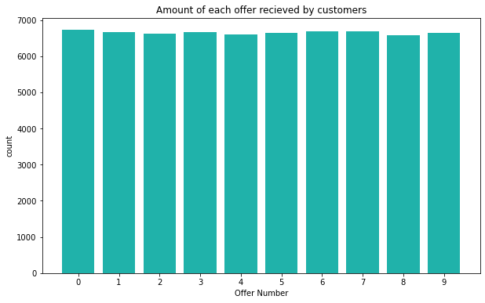

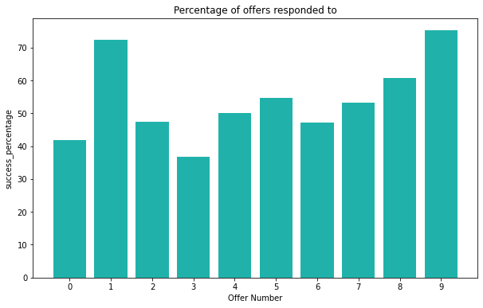

```python
#plotting the number of each offer recieved by customers and the success rate of each offer.
#This will be achieved by creating a offer_success_plotter function

def offer_success_plotter (df, column, title):
    """
    This function will seperate the dict values in the transaction_df
    ARGS:
        df - dataset
        column - column to be seperated
        title - title of the graph plotted
    """
    x = df.index
    y = df[column]

    fig=plt.figure(figsize = (10,6)) #size of bar_chart
    plt.bar(x, y, color = 'lightseagreen')
    plt.xticks(np.arange(0, len(x), 1)) #Ensuring each index is shown in the chart
    plt.xlabel('Offer Number')
    plt.ylabel(column)
    plt.title(title)
    plt.show()

#calling the offer_success_plotter() function to plot the graphs
offer_success_plotter (offers_response_df, 'count', 'Amount of each offer recieved by customers')

offer_success_plotter (offers_response_df, 'success_percentage', 'Percentage of offers responded to')
```

```python
combined_df.columns.tolist()
```

```
['customer_id',
 'offer_id',
 'time',
 'reward',
 'difficulty',
 'bogo',
 'discount',
 'informational',
 'web',
 'email',
 'mobile',
 'social',
 'duration_by_hours',
 'became_member_day',
 'membership_tenure',
 'age_grade_10s',
 'age_grade_20s',
 'age_grade_30s',
 'age_grade_40s',
 'age_grade_50s',
 'age_grade_60s',
 'age_grade_70s',
 'age_grade_80s',
 'age_grade_90s',
 'age_grade_100s',
 'income_range_30ths',
 'income_range_40ths',
 'income_range_50ths',
 'income_range_60ths',
 'income_range_70ths',
 'income_range_80ths',
 'income_range_90ths',
 'income_range_100ths',
 'income_range_110ths',
 'income_range_120ths',
 'year_2013',
 'year_2014',
 'year_2015',
 'year_2016',
 'year_2017',
 'year_2018',
 'month_1',
 'month_2',
 'month_3',
 'month_4',
 'month_5',
 'month_6',
 'month_7',
 'month_8',
 'month_9',
 'month_10',
 'month_11',
 'month_12',
 'gender_F',
 'gender_M',
 'gender_O',
 'total_amount',
 'cust_response']
```

## 2. Splitting into Training and Testing Sets and Modelling

In this section, we will split the dataset into training and testing sets, normalize with MinMaxScaler() as initialized with scaler and then fit into our models.

### 2.1 Benchmark Model

Benchmarking is the process of comparing models in their ability to learn patterns from a dataset. Flowing from this definition, 3 distinct classifiers (Logistic Regression, Random Forest Classifier, Gradient Boosting) will be trained with the data and their results compared with each other. The classifier or model with the highest accuracy will be chosen.

Recall that we had imported the following models and initalized them as such:

**lr = LogisticRegression(random_state=42), rfc = RandomForestClassifier(random_state=42), gbc = GradientBoostingClassifier(random_state=42)**

Each of these models will be trained with data from our combined_df

### 2.2 Evaluation Metrics

evaluation metrics refers to a tool that measures the performance of a model . For this project, a confusion matrix will be generated detailing the True Positives (TP), False Positives (FP), False Negatives (FN), True Negatives (TN). The purpose of this is to depict the number of correct and wrong predictions made by the model. After this, the model’s accuracy score will be generated. Accuracy measures the ratio of correct predictions over the total number of instances evaluated. Formula for accuracy: (TP+TN)/(TP+TN+FP+FN)

```python
# Before spliting the dataset, we need to drop features from combined_data that are not required for training the model
combined_df.drop(columns=['customer_id', 'offer_id', 'time', 'email', 'became_member_day'], inplace=True)

#Let's see the columns after splitting
combined_df.columns.tolist()
```

```
['reward',
 'difficulty',
 'bogo',
 'discount',
 'informational',
 'web',
 'mobile',
 'social',
 'duration_by_hours',
 'membership_tenure',
 'age_grade_10s',
 'age_grade_20s',
 'age_grade_30s',
 'age_grade_40s',
 'age_grade_50s',
 'age_grade_60s',
 'age_grade_70s',
 'age_grade_80s',
 'age_grade_90s',
 'age_grade_100s',
 'income_range_30ths',
 'income_range_40ths',
 'income_range_50ths',
 'income_range_60ths',
 'income_range_70ths',
 'income_range_80ths',
 'income_range_90ths',
 'income_range_100ths',
 'income_range_110ths',
 'income_range_120ths',
 'year_2013',
 'year_2014',
 'year_2015',
 'year_2016',
 'year_2017',
 'year_2018',
 'month_1',
 'month_2',
 'month_3',
 'month_4',
 'month_5',
 'month_6',
 'month_7',
 'month_8',
 'month_9',
 'month_10',
 'month_11',
 'month_12',
 'gender_F',
 'gender_M',
 'gender_O',
 'total_amount',
 'cust_response']
```

```python
#Next, we are going to scale values in the  combined_df dataset. This will be done by a scale_features function

#A list of the features we want to scale
features_to_scale = ['difficulty', 'duration_by_hours', 'reward', 'membership_tenure', 'total_amount']

def scale_features(df, feat=features_to_scale):


    """
    This function will scale list features in a given dataframe

    ARGS:
        df (dataframe): dataframe having features to scale
        feat (list): list of features in dataframe to scale
    """

    # Prepare dataframe with features to scale
    df_feat_scale = df[feat]

    # Apply feature scaling to df
    df_feat_scale = pd.DataFrame(scaler.fit_transform(df_feat_scale), columns = df_feat_scale.columns,index=df_feat_scale.index)

    # Drop orignal features from df and add scaled features
    df = df.drop(columns=feat, axis=1)
    df_scaled = pd.concat([df, df_feat_scale], axis=1)

    return df_scaled

#Applying the scale_features column to the dataset
combined_df_scaled = scale_features(combined_df, feat=features_to_scale)

combined_df_scaled
```

|  | bogo | discount | informational | web | mobile | social | age_grade_10s | age_grade_20s | age_grade_30s | age_grade_40s | ... | month_12 | gender_F | gender_M | gender_O | cust_response | difficulty | duration_by_hours | reward | membership_tenure | total_amount |
| --- | --- | --- | --- | --- | --- | --- | --- | --- | --- | --- | --- | --- | --- | --- | --- | --- | --- | --- | --- | --- | --- |
| 0 | 1 | 0 | 0 | 1 | 1 | 0 | 0 | 0 | 0 | 0 | ... | 0 | 1 | 0 | 0 | 1 | 0.25 | 0.571429 | 0.5 | 0.243006 | 0.033137 |
| 1 | 0 | 0 | 1 | 0 | 1 | 1 | 0 | 0 | 0 | 0 | ... | 0 | 1 | 0 | 0 | 1 | 0.00 | 0.000000 | 0.0 | 0.243006 | 0.043447 |
| 2 | 1 | 0 | 0 | 0 | 1 | 1 | 0 | 0 | 0 | 0 | ... | 0 | 1 | 0 | 0 | 1 | 0.50 | 0.571429 | 1.0 | 0.243006 | 0.042471 |
| 3 | 1 | 0 | 0 | 1 | 1 | 1 | 0 | 0 | 0 | 0 | ... | 0 | 1 | 0 | 0 | 1 | 0.25 | 0.285714 | 0.5 | 0.243006 | 0.042471 |
| 4 | 0 | 1 | 0 | 1 | 1 | 0 | 0 | 0 | 0 | 0 | ... | 0 | 0 | 1 | 0 | 0 | 0.50 | 0.571429 | 0.2 | 0.049918 | 0.000000 |
| ... | ... | ... | ... | ... | ... | ... | ... | ... | ... | ... | ... | ... | ... | ... | ... | ... | ... | ... | ... | ... | ... |
| 66496 | 0 | 1 | 0 | 1 | 1 | 0 | 0 | 0 | 0 | 0 | ... | 0 | 0 | 1 | 0 | 0 | 0.50 | 0.571429 | 0.2 | 0.186506 | 0.029944 |
| 66497 | 0 | 0 | 1 | 0 | 1 | 1 | 0 | 0 | 0 | 1 | ... | 0 | 0 | 1 | 0 | 1 | 0.00 | 0.000000 | 0.0 | 0.196380 | 0.017523 |
| 66498 | 1 | 0 | 0 | 1 | 1 | 0 | 0 | 0 | 0 | 0 | ... | 0 | 0 | 1 | 0 | 0 | 0.25 | 0.571429 | 0.5 | 0.051563 | 0.025000 |
| 66499 | 0 | 1 | 0 | 1 | 1 | 1 | 0 | 0 | 0 | 0 | ... | 1 | 1 | 0 | 0 | 1 | 0.35 | 0.571429 | 0.3 | 0.117937 | 0.066715 |
| 66500 | 0 | 1 | 0 | 1 | 1 | 1 | 0 | 1 | 0 | 0 | ... | 0 | 0 | 1 | 0 | 1 | 0.35 | 0.571429 | 0.3 | 0.353812 | 0.012535 |

66501 rows × 53 columns

```python
# splitting the dataset

# x are the independece variables that act as the input of the model
X = combined_df_scaled.drop(columns=['cust_response'])

# y is the variable to we are trying to predict predict
y = combined_df_scaled['cust_response']

# split data into train and test sets with train_test_split()
X_train, X_test, y_train, y_test = train_test_split(X, y, test_size=0.3, random_state=42)
```

```python
#Next we are going to calculate the distribution of target values in the y_train set (i.e 1s and 0s)
#This will tell us if the training is balanced or imbalanced

round((y_train.squeeze().value_counts()/y_train.squeeze().count())*100,2)

#From the answer below, we can tell that the training set is almost balanced. It is not extremely imbalanced.
#As such, no need to worry about dealing with class imbalance
```

```
1    53.8
0    46.2
Name: cust_response, dtype: float64
```

```python
#Next, we are going to train the three models we have outlined and choose any of them based on the model's score
#This will be done by creating a function called classifier_trainer
# The model with the highest score will be chosen to predict values based on the X_test
#After this, a confusion matrix will be generated to ascertain the True Positives (TP), False Positives (FP), False Negatives (FN), True Negatives (TN).

def classifier_trainer(X_train, y_train):
    """
    This function trains the identified classifers with the X_train and y_train sets
    ARGS:
        X_train - Independent variables (Features) training set
        y_train - Dependent variable (Target) training set
        """
    classifiers = [lr, rfc, gbc]
    for classifier in classifiers:
        training = classifier.fit(X_train, y_train)
        score = 'Classifier_Score : {}'.format(classifier.score(X_train, y_train))
        line_breaker = '*****************************'
        print(training)
        print(score)
        print(line_breaker)


classifier_trainer(X_train, y_train)
```

```
LogisticRegression(random_state=42)
Classifier_Score : 0.8416111707841031
RandomForestClassifier(random_state=42)
Classifier_Score : 0.9999355531686359
GradientBoostingClassifier(random_state=42)
Classifier_Score : 0.9114285714285715
```

The preceding represents the training scores of the identified models. The next step is to generate the test accuracy of the model

```python
from sklearn.metrics import accuracy_score

def classifier_tester(X_test):
    """
    This function tests the identified classifiers with the X_test set
    ARGS:
        X_test - Independent variables (Features) testing set
        """
    classifiers = [lr, rfc, gbc]
    for classifier in classifiers:
        testing = classifier.predict(X_test)
        score = 'Classifier_test_Score : {}'.format(classifier.score(X_test, y_test))
        line_breaker = '*****************************'
        print(classifier.__class__.__name__)
        print(score)
        print(line_breaker)

classifier_tester(X_test)
```

```
LogisticRegression
Classifier_test_Score : 0.8434664929076237
RandomForestClassifier
Classifier_test_Score : 0.9252669039145908
GradientBoostingClassifier
Classifier_test_Score : 0.9099794496516466
```

From the training and testing scores above, we can conclude that the Random Forest Classifier out performs the other models with a training and testing accuracy of 0.999 and 0.925 respectively. As a result, we will move forward with the Random Forest Classifier

```python
#making predictions with the RandomForestClassifier
y_pred = rfc.predict(X_test)
y_pred
```

```
array([0, 1, 1, ..., 0, 0, 1])
```

```
True positive =  8111
False positive =  1028
False negative =  463
True negative =  10349
```

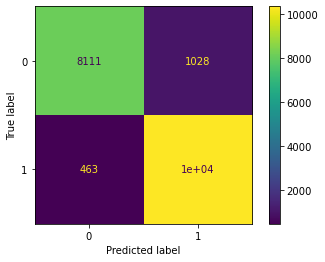

```python
#We will also plot the confusion matrix.
#To make the plot easily understandable, we will also list out the TP, FP, FN, TN. this will be done by a print_confusion_matrix function
from sklearn.metrics import plot_confusion_matrix
plot_confusion_matrix(rfc, X_test, y_test, include_values = True)

def print_confusion_matrix(y_test, y_pred):
    """
    This function prints out the TP, FP, FN and TN
    ARGS:
        y_test - the true values of y
        y_pred - the predicted values of y
    """
    cm = confusion_matrix(y_test, y_pred)
    print('True positive = ', cm[0][0])
    print('False positive = ', cm[0][1])
    print('False negative = ', cm[1][0])
    print('True negative = ', cm[1][1])

print_confusion_matrix(y_test, y_pred)
```

from the confusion matrix above, we see that the false positives and negatives are a bit high, although the model performed well. Hence, we will tune the RandomClassifierModel

```python
clf = RandomForestClassifier(n_estimators=60,criterion='entropy',random_state=42)
clf.fit(X_train, y_train)

#Predicting with the tuned model
y_pred = clf.predict(X_test)
y_pred
```

```
array([0, 1, 1, ..., 0, 0, 1])
```

```
True positive =  8111
False positive =  1028
False negative =  450
True negative =  10362
```

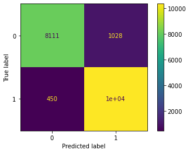

```python
#plotting the confusion matrix of the predictions as made by the tuned model
plot_confusion_matrix(clf, X_test, y_test, include_values = True)

print_confusion_matrix(y_test, y_pred)
```

# 3. Results

This section presents the results of the project

## 3.1 Idenitifying the Most Influential Features

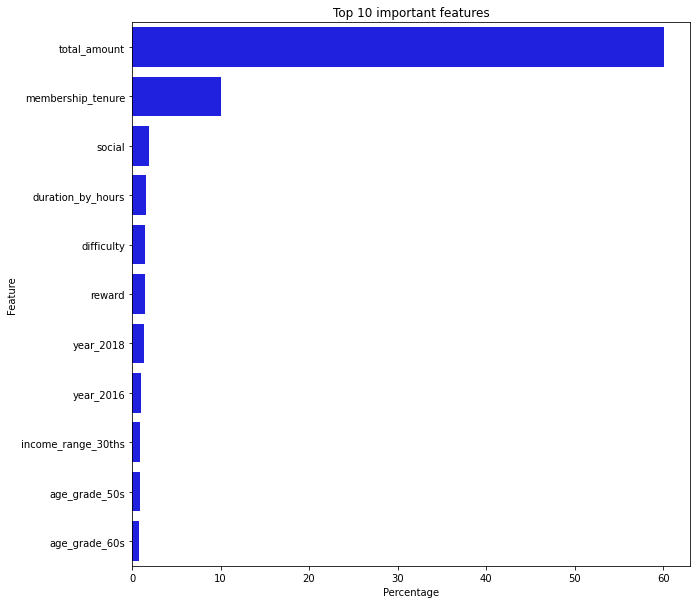

```python
feature_imp = pd.DataFrame(rfc.feature_importances_,index=X_train.columns.tolist(),columns=['feat_imp']).reset_index()
feature_imp.rename(columns={'index': 'feature'}, inplace=True)
feature_imp['feat_imp_rate'] = np.round((feature_imp['feat_imp']/feature_imp['feat_imp'].sum())*100,2)
feature_imp = feature_imp.sort_values(by=['feat_imp_rate'], ascending=False).reset_index(drop=True)
feature_imp.drop(columns=['feat_imp'],inplace=True)

fig, ax = plt.subplots(figsize=(10, 10),nrows=1,ncols=1)
sns.barplot(x=feature_imp.loc[0:10,'feat_imp_rate'], y=feature_imp.loc[0:10,'feature'], color='blue', data=feature_imp)
plt.xlabel('Percentage')
plt.ylabel('Feature')
plt.title('Top 10 important features')
plt.show()
```

**Total Amount:** The total amount of money spent by a customer will determine to a large extent, if they will respond to an offer or no

**membership tenure:** The membership tenure of customers also determines if they will respond to an offer or not